# Machine Learning-Decision Trees

Max Flurie

2021-05-09

# 1 1. Libraries

# 2 Libraries

```r
library(rpart)
library(readr)
library(caTools)
library(rstatix)
library(dplyr)
library(party)
library(partykit)
library(rpart.plot)
library(ggplot2)
max.theme <- theme_bw() + theme(axis.line = element_line(colour = "black"), panel.grid.minor = element_blank(), panel.grid.major = element_blank(), panel.border = element_blank(), panel.background = element_blank(), legend.title= element_blank())
```

# 3 Introduction: Binary Decision Trees

The ‘Titanic’ data set is a great data set for machine learning: specifically Decision Trees with a binary response. Initially, I was going to start with some “real world” data to demonstate this process in R, but after investigating some other tutorials with the ‘Titanic’ data, I noticed many have incomplete (and sometimes incorrect) code. So, I will start with the ‘Titanic’ data and then show another example with some clinical data. We begin in 1912…

**The Titanic Dataset:**

*survival*: 0 = No, 1 = Yes

*pclass*: (Ticket Class): 1 = 1st, 2 = 2nd, 3 = 3rd

*sex*

*age*

*sibsp*: # of siblings / spouses aboard the Titanic

*parch*: # of parents / children aboard the Titanic

*ticket*: Ticket number

*fare*: Passenger fare

*cabin*: Cabin number

*embarked*: Port of Embarkation C = Cherbourg, Q = Queenstown, S = Southampton

# 4 Load in Data

```r
titanic<-read_csv("titanicdata.csv")
head(titanic)
```

| x | pclass | survived | name | sex | age | sibsp | parch | ticket | fare | cabin | embarked | home.dest |
| --- | --- | --- | --- | --- | --- | --- | --- | --- | --- | --- | --- | --- |
| 1 | 1 | 1 | Allen, Miss. Elisabeth Walton | female | 29 | 0 | 0 | 24160 | 211.3375 | B5 | S | St Louis, MO |
| 2 | 1 | 1 | Allison, Master. Hudson Trevor | male | 0.9167 | 1 | 2 | 113781 | 151.5500 | C22 C26 | S | Montreal, PQ / Chesterville, ON |
| 3 | 1 | 0 | Allison, Miss. Helen Loraine | female | 2 | 1 | 2 | 113781 | 151.5500 | C22 C26 | S | Montreal, PQ / Chesterville, ON |
| 4 | 1 | 0 | Allison, Mr. Hudson Joshua Creighton | male | 30 | 1 | 2 | 113781 | 151.5500 | C22 C26 | S | Montreal, PQ / Chesterville, ON |
| 5 | 1 | 0 | Allison, Mrs. Hudson J C (Bessie Waldo Daniels) | female | 25 | 1 | 2 | 113781 | 151.5500 | C22 C26 | S | Montreal, PQ / Chesterville, ON |
| 6 | 1 | 1 | Anderson, Mr. Harry | male | 48 | 0 | 0 | 19952 | 26.5500 | E12 | S | New York, NY |

# 5 Shuffle the Data

This is good practice when creating ‘training’ and ‘test’ sets of data. Otherwise, your ‘training’ set might be missing a category of data if your data is ranked in any way (e.g., ‘pclass’ in this data set). You would end up training our data on one type of ‘pclass’ even though their are three ‘pclass’ types (e.g., First Class, Second Class, Third Class tickets).

```r
#Prep shuffle
shuffleTitanic <- sample(1:nrow(titanic))
head(shuffleTitanic)
```

```
## [1] 269 707 968 569 349 727
```

```r
#Shuffle it up
titanic <- titanic[shuffleTitanic, ]
head(titanic)
```

| x | pclass | survived | name | sex | age | sibsp | parch | ticket | fare | cabin | embarked | home.dest |
| --- | --- | --- | --- | --- | --- | --- | --- | --- | --- | --- | --- | --- |
| 269 | 1 | 0 | Smith, Mr. Lucien Philip | male | 24 | 1 | 0 | 13695 | 60.0000 | C31 | S | Huntington, WV |
| 707 | 3 | 0 | Caram, Mrs. Joseph (Maria Elias) | female | ? | 1 | 0 | 2689 | 14.4583 | ? | C | Ottawa, ON |
| 968 | 3 | 0 | Lindblom, Miss. Augusta Charlotta | female | 45 | 0 | 0 | 347073 | 7.7500 | ? | S | ? |
| 569 | 2 | 0 | Swane, Mr. George | male | 18.5 | 0 | 0 | 248734 | 13.0000 | F | S | ? |
| 349 | 2 | 0 | Bracken, Mr. James H | male | 27 | 0 | 0 | 220367 | 13.0000 | ? | S | Lake Arthur, Chavez County, NM |
| 727 | 3 | 0 | Connolly, Miss. Kate | female | 30 | 0 | 0 | 330972 | 7.6292 | ? | Q | Ireland |

Now we see ‘pclass’ is randomized nicely.

# 6 Clean the Data

Let’s get rid of variables we won’t be using.

```r
# Drop variables of non-interest
clean_titanic <- titanic %>%
select(-c(home.dest, cabin, name, x, ticket)) %>%
#Convert column codings to factors with descriptive names
    mutate(pclass = factor(pclass, levels = c(1, 2, 3), labels = c('First', 'Second', 'Third')),
    survived = factor(survived, levels = c(0, 1), labels = c('Died', 'Survived'))) %>%
na.omit()
#remove all ? values
clean_titanic <- subset(clean_titanic, age!="?")
#convert columns to appropriate data type
clean_titanic$sex<-as.factor(clean_titanic$sex)
clean_titanic$age<-as.double(clean_titanic$age)
clean_titanic$sibsp<-as.integer(clean_titanic$sibsp)
clean_titanic$parch<-as.integer(clean_titanic$parch)
clean_titanic$fare<-as.double(clean_titanic$fare)
clean_titanic$embarked<-as.factor(clean_titanic$embarked)
clean_titanic<-as.data.frame(clean_titanic)
#check it out
glimpse(clean_titanic)
```

```
## Rows: 1,045
## Columns: 8
## $ pclass   <fct> First, Third, Second, Second, Third, First, First, First, Th…
## $ survived <fct> Died, Died, Died, Died, Died, Survived, Died, Survived, Surv…
## $ sex      <fct> male, female, male, male, female, female, male, male, female…
## $ age      <dbl> 24.0, 45.0, 18.5, 27.0, 30.0, 27.0, 50.0, 43.0, 47.0, 35.0, …
## $ sibsp    <int> 1, 0, 0, 0, 0, 1, 0, 1, 1, 0, 8, 2, 0, 0, 0, 1, 1, 0, 0, 1, …
## $ parch    <int> 0, 0, 0, 0, 0, 1, 0, 0, 0, 0, 2, 0, 0, 0, 1, 0, 1, 0, 0, 1, …
## $ fare     <dbl> 60.0000, 7.7500, 13.0000, 13.0000, 7.6292, 247.5208, 26.0000…
## $ embarked <fct> S, S, S, S, Q, C, S, C, S, S, S, S, S, S, S, S, S, S, S, C, …
```

# 7 Make Train and Test Sets

We will take about 75% of the data to train the algorithm with and then use the remaining 25% to test and make predictions.

```r
set.seed(123)
sample_data = sample.split(clean_titanic, SplitRatio = 0.75)
train_data <- subset(clean_titanic, sample_data == TRUE)
test_data <- subset(clean_titanic, sample_data == FALSE)

dim(train_data) #check rows in each dataframe
```

```
## [1] 784   8
```

```r
dim(test_data)
```

```
## [1] 261   8
```

```r
prop.table(table(train_data$survived)) #make sure outcomes are similar
```

```
##
##      Died  Survived
## 0.6045918 0.3954082
```

```r
prop.table(table(test_data$survived))
```

```
##
##      Died  Survived
## 0.5517241 0.4482759
```

# 8 Make Decision Tree

Here we have our Decision Tree. They can be a bit confusing, but you can make other descriptive tables to double-check your interpretations. It is important also to note that you will get different results each time your run your model, but the results should be quite similar. In other words, your output should be within a percent or two each time. To demonstrate this point, I will show you a new model output (the Decision Tree Plot) but describe a previous iteration of the plot. You will see my descriptions might be off by a percentage or two, but will offer the same general message.

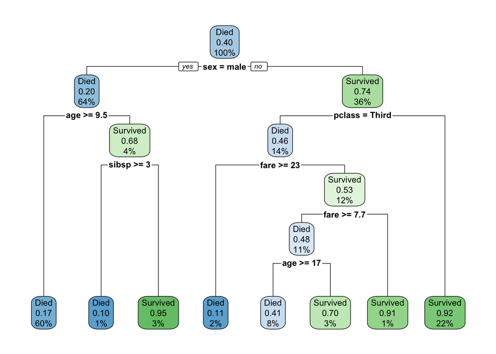

```r
fit <- rpart(survived~., data = train_data, method = 'class') #"class"
rpart.plot(fit)
```

**Each node shows:**

-the predicted class (died or survived)

-the predicted probability of survival

-the percentage of observations in the node

**Node 1-Overall:**

41% of all people survived

**Node 2-Gender:**

Probability of survival was 74% (38% of total population) for females

**Node 3-Females:**

Odds of survival are 46% for third class females (15% of total population)

Odds of survival are 93% for first/second class females (23% of total population)

**Check your interpretation with frequency tables**

When learning how to interpret Trees and/or Leaves, you can make frequency tables for subsets of the data to make sure it aligns with your interpretation.

```r
freq_table(clean_titanic$survived) #explains Node 1
```

| group | n | prop |
| --- | --- | --- |
| Died | 618 | 59.1 |
| Survived | 427 | 40.9 |

```r
freq_table(clean_titanic$sex) #explains Node 2
```

| group | n | prop |
| --- | --- | --- |
| female | 388 | 37.1 |
| male | 657 | 62.9 |

# 9 Make Predictions with Test Data

```r
#make predictions with test data
predictFit <-predict(fit, test_data, type = 'class')
#summarize predictions
fitTable <- table(test_data$survived, predictFit)
fitTable
```

```
##           predictFit
##            Died Survived
##   Died      134       10
##   Survived   43       74
```

# 10 Evaluate Prediction Performance

```r
predictionAccuracy <- sum(diag(fitTable)) / sum(fitTable)
predictionAccuracy
```

```
## [1] 0.7969349
```

# 11 A Clinical Example

Now we can use some real world clinical data. Here we have patients with different types of Primary Progressive Aphasia (svPPA and lvPPA). These patients named different kinds of pictures (e.g., objects, people, places). We want to evaluate which factors are important for increased naming accuracy in patients.

**The PPA Dataset:**

The following decribes the data for variables we keep for the Decision Tree only (see output after “Clean the Data”)

*DX*: PPA type: svPPA (semantic variant Primary Progressive Aphasia), lvPPA (logopenic variant Primary Progressive Aphasia), AD (Alzheimer’s Disease)

*Year Onset*: Year Disease symptoms began

*Edu*: Years of Education

*TimePoint*: We remove all but T1 (when they were first assessed)

*AgeAtTest*: Patient age when they were assessed

*Acc*: 0-Incorrectly named, 1-Correctly named

*Sem.cat*: category of item (i.e., did they name a picture of a person, place, or object)

# 12 Load in Data

```r
lex<-read_csv("LexData.csv")
head(lex)
```

| Patient | Dx | YearOnset | Edu | TimePoint | AgeAtTest | BNT | PPTpics | PPTwords | MoCA | DigitsF | DigitsB | Condition | Category | Acc |
| --- | --- | --- | --- | --- | --- | --- | --- | --- | --- | --- | --- | --- | --- | --- |
| S04 | svPPA | 2011 | 15 | T2 | 66 | 2 | 16 | NA | 13 | 6 | 5 | control | activity | 1 |
| S06 | lvPPA | 2011 | 14 | T2 | 65 | 14 | 21 | 23 | 15 | 3 | 2 | train | clothes | 1 |
| S05 | lvPPA | 2012 | 13 | T1 | 69 | 11 | 26 | 26 | 15 | 5 | 6 | control | food | 1 |
| S06 | lvPPA | 2011 | 14 | T1 | 65 | 12 | 25 | 24 | 15 | 4 | 2 | control | hygiene | 1 |
| S06 | lvPPA | 2011 | 14 | T1 | 65 | 12 | 25 | 24 | 15 | 4 | 2 | control | clothes | 1 |
| S06 | lvPPA | 2011 | 14 | T5 | 67 | 10 | 23 | 24 | 10 | NA | NA | control | household | 1 |

# 13 Shuffle the Data

```r
#Prep shuffle
shufflelex <- sample(1:nrow(lex))
head(shufflelex)
```

```
## [1] 5398 5521 4750 4325 2423 1600
```

```r
#Shuffle it up
lex <- lex[shufflelex, ]
head(lex)
```

| Patient | Dx | YearOnset | Edu | TimePoint | AgeAtTest | BNT | PPTpics | PPTwords | MoCA | DigitsF | DigitsB | Condition | Category | Acc |
| --- | --- | --- | --- | --- | --- | --- | --- | --- | --- | --- | --- | --- | --- | --- |
| S17 | svPPA | 2013 | 12 | T5 | 67 | 4 | 20 | 18 | 13 | 5 | 6 | control | place | 0 |
| S18 | svPPA | 2015 | 16 | T4 | 67 | 4 | 19 | 17 | 18 | 7 | 10 | control | place | 0 |
| S04 | svPPA | 2011 | 15 | T5 | 67 | 1 | 12 | 12 | 7 | 5 | 5 | train | hygiene | 0 |
| S04 | svPPA | 2011 | 15 | T5 | 67 | 1 | 12 | 12 | 7 | 5 | 5 | control | household | 0 |
| S17 | svPPA | 2013 | 12 | T3 | 66 | 4 | 25 | 23 | 17 | 5 | 6 | train | activity | 1 |
| S12 | svPPA | 2012 | 18 | T1 | 64 | 3 | 23 | 25 | 17 | 7 | 7 | control | food | 1 |

# 14 Clean the Data

Let’s get rid of variables we won’t be using.

```r
# Drop variables of non-interest
clean_lex <- lex %>%
select(-c(Patient, BNT, PPTpics, MoCA, DigitsF, DigitsB, PPTwords, Condition))
clean_lex$Dx<-(sapply(clean_lex$Dx, tolower))
clean_lex <-subset(clean_lex, TimePoint=="T1")
clean_lex$Dx <- ifelse(clean_lex$Dx == "svppa/bvftd",  "svppa",
                       ifelse(clean_lex$Dx == "svppa", "svppa",
                       ifelse(clean_lex$Dx == "lvppa", "lvppa",
                       ifelse(clean_lex$Dx == "ad", "ad","NA"))))
#Reduce Categories
clean_lex <- clean_lex  %>%
  mutate(sem.cat = ifelse(Category== "people", "people",
                   ifelse(Category=="hygiene" | Category=="food" |     Category=="household" |  Category=="clothes", "objects",
                          ifelse(Category=="place", "places", "NA"))))
#Drop NAs in new category
clean_lex <- subset(clean_lex, sem.cat!="NA")
#Drop the old category column and TimePoint
clean_lex <- clean_lex %>%
select(-c(Category, TimePoint))
#convert columns to appropriate data type
clean_lex$Dx<-as.factor(clean_lex$Dx)
clean_lex$sem.cat<-as.factor(clean_lex$sem.cat)
#change outcome variable factor name
clean_lex$Acc <- factor(clean_lex$Acc, levels = c(0, 1), labels = c('Incorrect', 'Correct'))
clean_lex$Acc<-as.factor(clean_lex$Acc) # make factor
#make sure you have a dataframe
clean_lex<-as.data.frame(clean_lex)
#check it out
glimpse(clean_lex)
```

```
## Rows: 1,315
## Columns: 6
## $ Dx        <fct> svppa, svppa, lvppa, svppa, svppa, lvppa, svppa, ad, svppa,…
## $ YearOnset <dbl> 2012, 2012, 2011, 2011, 2010, 2011, 2011, 2000, 2013, 2000,…
## $ Edu       <dbl> 18, 18, 14, 12, 16, 14, 15, 16, 12, 16, 16, 12, NA, 14, 13,…
## $ AgeAtTest <dbl> 64, 64, 65, 59, 60, 65, 65, 79, 65, 79, 79, 65, 65, 65, 69,…
## $ Acc       <fct> Correct, Correct, Correct, Correct, Incorrect, Correct, Cor…
## $ sem.cat   <fct> objects, objects, objects, objects, objects, places, object…
```

# 15 Make Train and Test Sets

```r
set.seed(1234)
sample_data2 = sample.split(clean_lex, SplitRatio = 0.75)
train_data2 <- subset(clean_lex, sample_data2 == TRUE)
test_data2 <- subset(clean_lex, sample_data2 == FALSE)

dim(train_data2) #check rows in each dataframe
```

```
## [1] 877   6
```

```r
dim(test_data2)
```

```
## [1] 438   6
```

```r
prop.table(table(train_data2$Acc)) #make sure outcomes are similar
```

```
##
## Incorrect   Correct
## 0.3375143 0.6624857
```

```r
prop.table(table(test_data2$Acc))
```

```
##
## Incorrect   Correct
## 0.3721461 0.6278539
```

# 16 Make Decision Tree

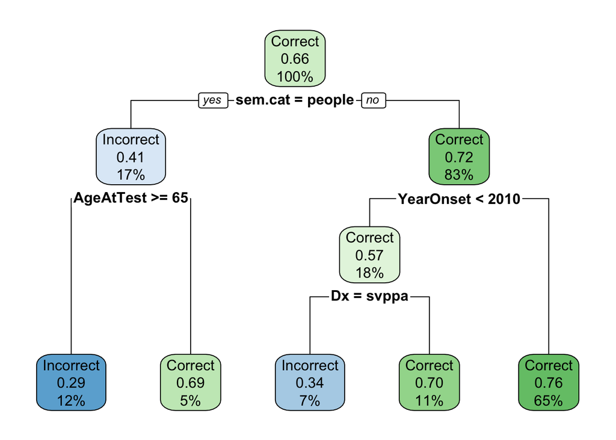

```r
set.seed(123)
fit2 <- rpart(Acc~., data = train_data2, method = 'class') #"class" for binary model
rpart.plot(fit2)
```

Like our Titanic Decision Tree, output will be slightly different with new iterations of the model. Across iterations, however, we should be able to discern important factors that impact naming accuracy.

**Each node shows:**

-the predicted class (Incorrect or Correct)

-the predicted probability of correctly naming

-the percentage of observations in the node

**Node 1-Overall:**

66% of all picture were named correctly

**Node 2-Semantic Category:**

Probability of correctly naming picture was 39% (18% of all pictures) for ‘people’ pictures

Probability of correctly naming picture was 72% (82% of all pictures) for ‘non-people’ pictures (objects, places)

**Check your interpretation with frequency tables**

```r
library(gmodels)
freq_table(clean_lex$Acc) #explains Node 1
```

| group | n | prop |
| --- | --- | --- |
| Incorrect | 459 | 34.9 |
| Correct | 856 | 65.1 |

```r
freq_table(clean_lex$sem.cat) #explains Node 2
```

| group | n | prop |
| --- | --- | --- |
| objects | 846 | 64.3 |
| people | 234 | 17.8 |
| places | 235 | 17.9 |

```r
CrossTable(clean_lex$sem.cat, clean_lex$Acc) #explains Node 2
```

```
##
##
##    Cell Contents
## |-------------------------|
## |                       N |
## | Chi-square contribution |
## |           N / Row Total |
## |           N / Col Total |
## |         N / Table Total |
## |-------------------------|
##
##
## Total Observations in Table:  1315
##
##
##                   | clean_lex$Acc
## clean_lex$sem.cat | Incorrect |   Correct | Row Total |
## ------------------|-----------|-----------|-----------|
##           objects |       251 |       595 |       846 |
##                   |     6.645 |     3.563 |           |
##                   |     0.297 |     0.703 |     0.643 |
##                   |     0.547 |     0.695 |           |
##                   |     0.191 |     0.452 |           |
## ------------------|-----------|-----------|-----------|
##            people |       142 |        92 |       234 |
##                   |    44.551 |    23.889 |           |
##                   |     0.607 |     0.393 |     0.178 |
##                   |     0.309 |     0.107 |           |
##                   |     0.108 |     0.070 |           |
## ------------------|-----------|-----------|-----------|
##            places |        66 |       169 |       235 |
##                   |     3.131 |     1.679 |           |
##                   |     0.281 |     0.719 |     0.179 |
##                   |     0.144 |     0.197 |           |
##                   |     0.050 |     0.129 |           |
## ------------------|-----------|-----------|-----------|
##      Column Total |       459 |       856 |      1315 |
##                   |     0.349 |     0.651 |           |
## ------------------|-----------|-----------|-----------|
##
##
```

# 17 Make Predictions with Test Data

```r
#make predictions with test data
predictFit2 <-predict(fit2, test_data2, type = 'class')
#summarize predictions
fitTable2 <- table(test_data2$Acc, predictFit2)
fitTable2
```

```
##            predictFit2
##             Incorrect Correct
##   Incorrect        64      99
##   Correct          18     257
```

# 18 Evaluate Prediction Performance

```r
predictionAccuracy2 <- sum(diag(fitTable2)) / sum(fitTable2)
predictionAccuracy2
```

```
## [1] 0.7328767
```